# TitanicSurivors

## LOOKING AT DATA & UNDERSTANDING RELATIONSHIPS

##### Looking at the relationship of age with other variables as possible method of imputing Age values.

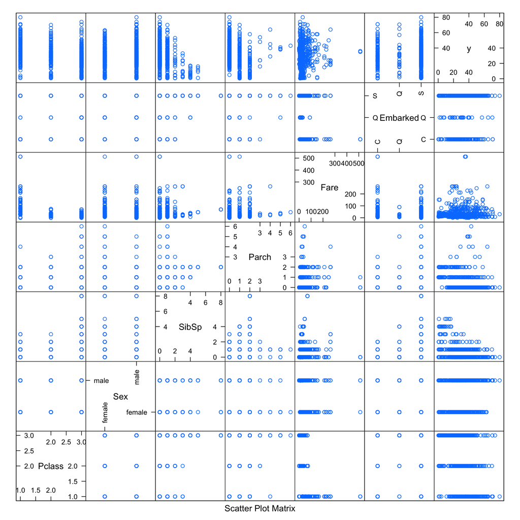

```r
# Relationship of Age (y) with other factors
featurePlot(x = DataFile[, c(3, 5, 7,8,10,12)],
            y = DataFile$Age,
            plot = "pairs")
```

##### It can be seen that age is somewhat correlated with # of Parent/children or number of siblings. This makes sense as a child would generally have at most 2 parents while a parent can have higher number of children, so if a passenger has a higher value of SibSp, it should be a good indicator of the Age values.

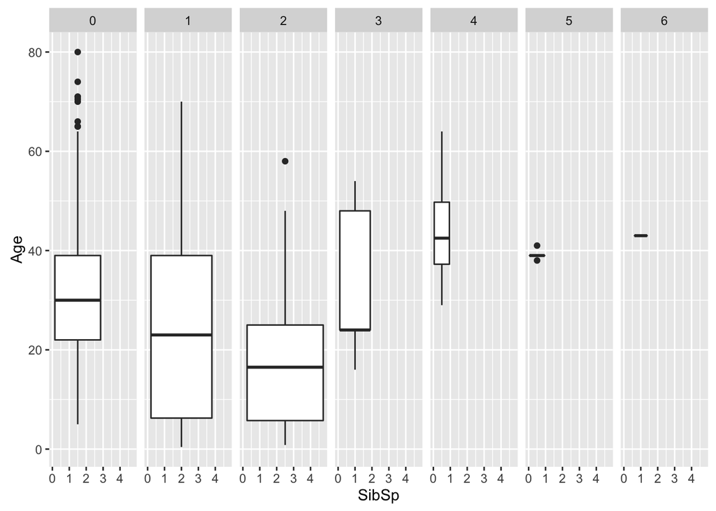

```r
#Getting the Denomination of the passenger and add it to the data frame
First <- gsub(pattern= ".*\\, ", replacement="", DataFile$Name)
Denomination= gsub(pattern= "\\. .*", replacement="", First)
DataFile <- mutate(DataFile,
             #Adding name denomination to the data frame
             Denomination=Denomination)

ggplot(DataFile, aes(x=SibSp, y=Age))+facet_grid(.~Parch)+geom_boxplot()
```

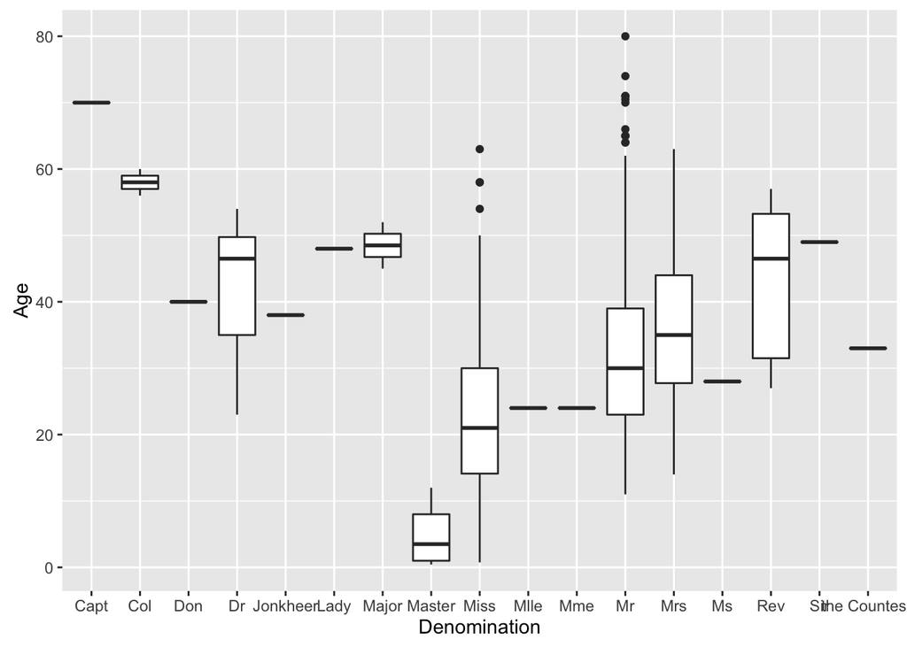

```r
ggplot(DataFile, aes(x=Denomination, y=Age))+geom_boxplot()
```

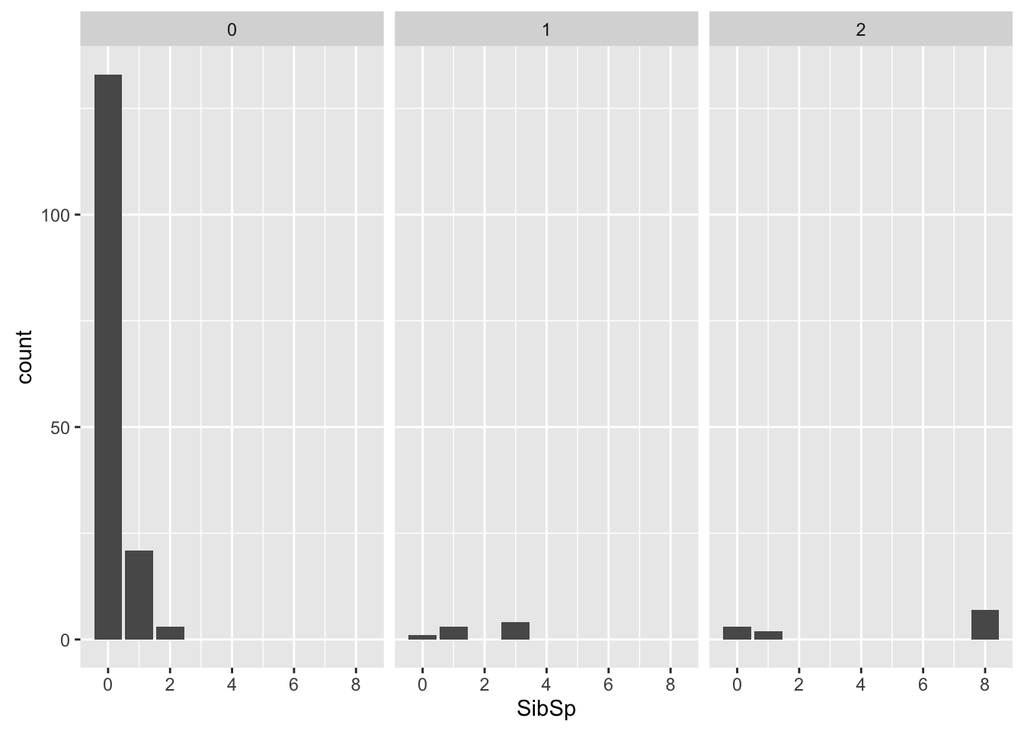

```r
ggplot(filter(DataFile, is.na(Age)), aes(x=SibSp))+facet_grid(.~Parch)+geom_bar()
```

- Since most of missing Age values are for the Parch of 0 (and 1 or 2), SibSp can be used for filling in the value of the age.
- However, name may be a better estimate with narrower estimation ranges for each category.
- Furthermore Pclass is not a good estimator of age, as the age distribution is fairly uniform for all the classes.

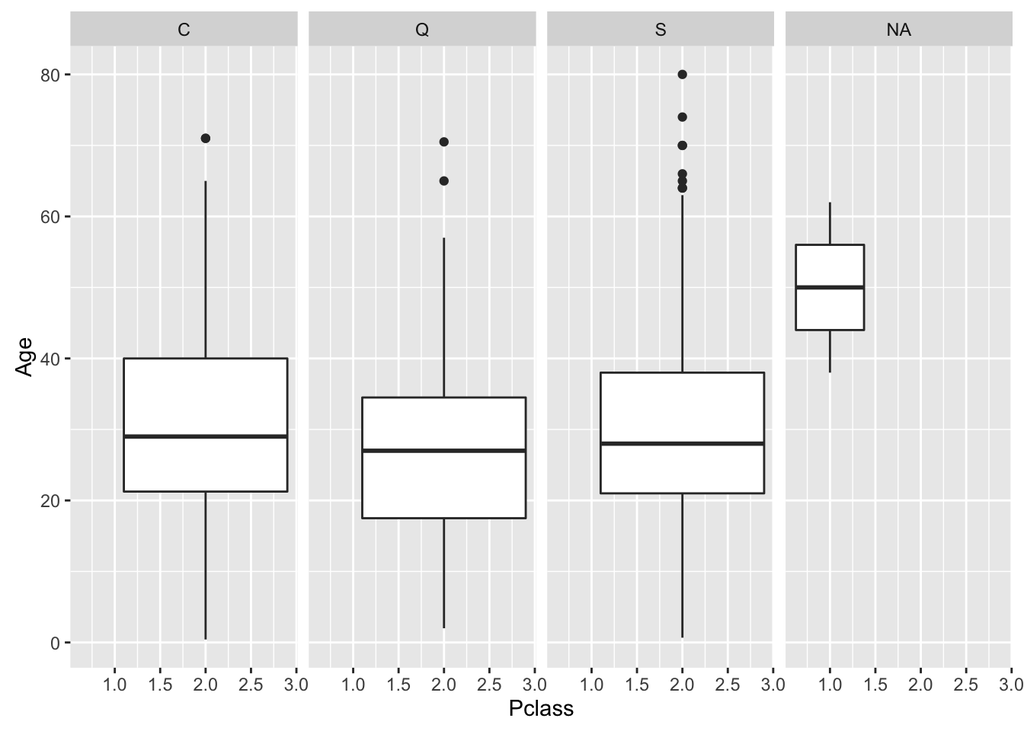

```r
ggplot(DataFile, aes(x=Pclass, y=Age))+geom_boxplot()+facet_grid(.~Embarked)
```

- For fare, Class of the passenger has a stronger effect than the port of embarkation. Hence it may be reasonable to impute the values with the median fare of the PClass of the passenger.

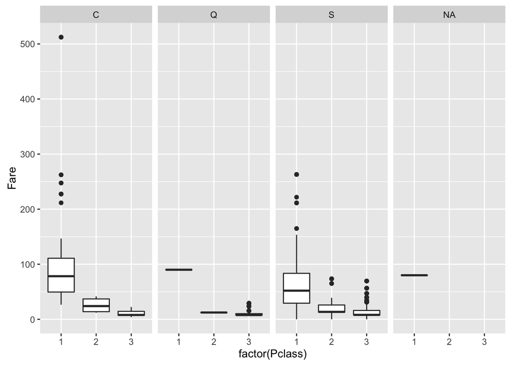

```r
ggplot(DataFile, aes(x=factor(Pclass), y=Fare))+geom_boxplot()+facet_grid(.~Embarked)
```